# Blocking Example

```r
library(tidyverse)
library(tidybayes)
library(generative)
review_theme()
```

- First, generate a design, specifying which people are given which treatments and which control
- Then, write a function that simulates data given the design
- Then write a function to estimate unknown effects given a design
- Loop that function over a few designs and many simulated datasets, to come up with notion of power

```r
N <- 60
designs <- list(
  "basic" = basic_design(N),
  "blocked" = blocked_design(N),
  "compromise" = compromise_design(N)
)

designs
```

| id | subject | treatment |
| --- | --- | --- |
| 1 | 1 | C |
| 2 | 2 | B |
| 3 | 3 | A |
| 4 | 4 | B |
| 5 | 5 | A |
| 6 | 6 | A |
| 7 | 7 | C |
| 8 | 8 | C |
| 9 | 9 | B |
| 10 | 10 | C |

[output cut: 50 more lines]

| id | subject | treatment |
| --- | --- | --- |
| 1 | 1 | B |
| 2 | 1 | A |
| 3 | 1 | C |
| 4 | 2 | B |
| 5 | 2 | A |
| 6 | 2 | C |
| 7 | 3 | B |
| 8 | 3 | C |
| 9 | 3 | A |
| 10 | 4 | B |

[output cut: 50 more lines]

| id | subject | treatment |
| --- | --- | --- |
| 1 | 1 | C |
| 2 | 1 | A |
| 4 | 2 | B |
| 5 | 2 | C |
| 7 | 3 | B |
| 8 | 3 | C |
| 10 | 4 | A |
| 11 | 4 | B |
| 13 | 5 | B |
| 14 | 5 | A |

[output cut: 50 more lines]

```
NA
```

Next, we provide a function to generate data given one of these designs.

```r
effects <- design_effects(N, 3, 25)
x_blocked <- simulate(designs$blocked, effects)
x_df <- bind_cols(designs$blocked, x_blocked) %>%
  pivot_longer(-c("id", "treatment", "subject"), names_to = "feature")
```

Here are some of the effects visible from the blocked design. The first 10 features have true effects, the rest don’t.

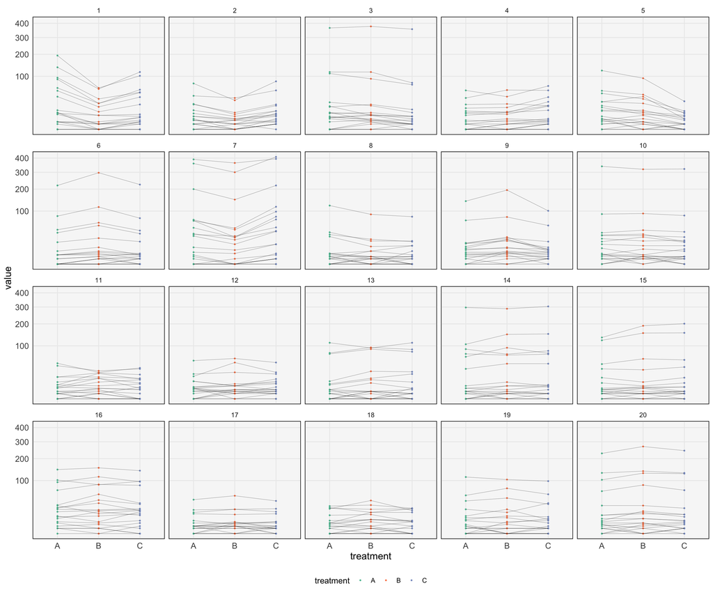

```r
plot_treatments(x_df) +
  geom_line(aes(group = subject), alpha = 0.4, size = 0.2)
```

This is the comparable figure if we didn’t have any blocking. Note that the feature-level treatment effects are exactly the same, but now we can’t draw lines linking the same individuals. The effects for the first 10 features are visible, but in some cases less obvious than when blocking was used.

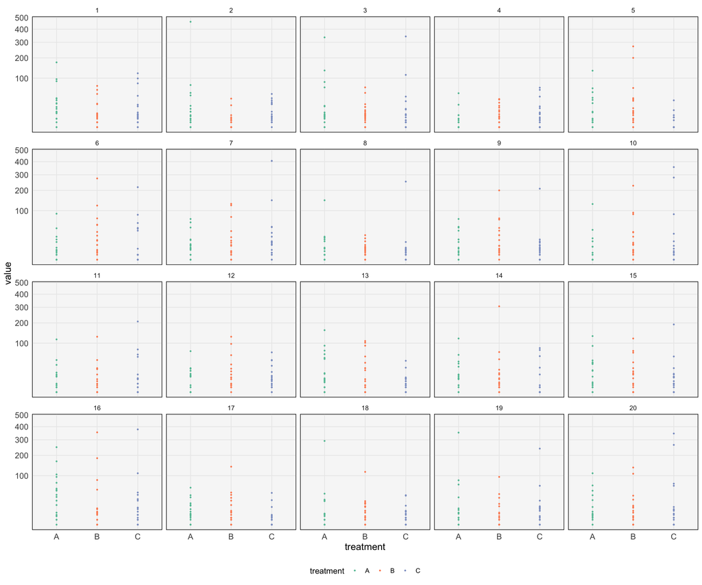

```r
x_basic <- simulate(designs$basic, effects)
x_df <- bind_cols(designs$basic, x_basic) %>%
  pivot_longer(-c("id", "treatment", "subject"), names_to = "feature")
plot_treatments(x_df)
```

Now we’ll write a small program to estimate the posterior on betas.

```r
fit <- multinomial_logistic(x_blocked, designs$blocked)
```

[output not shown]

[output cut: 192 more lines]

[output not shown]

```r
treatment_estimates <- list()
treatment_estimates[["blocked"]] <- process_estimate(fit, "treatment")
truth <- process_truth(effects$treatment)
```

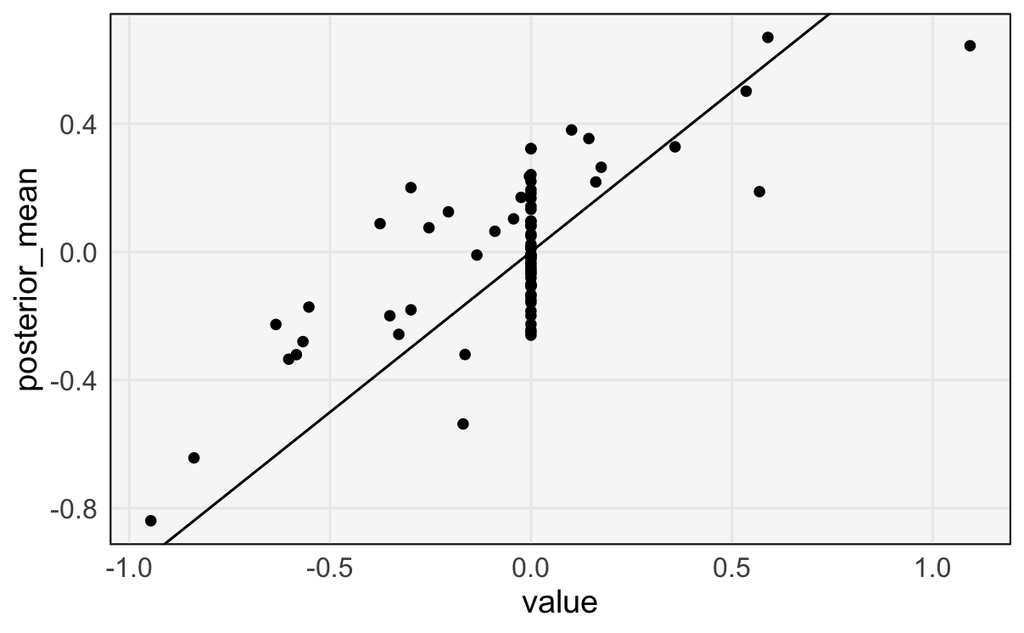

```r
comparison <- treatment_estimates$blocked %>%
  group_by(feature, treatment) %>%
  summarise(posterior_mean = mean(value)) %>%
  left_join(truth)
ggplot(comparison) +
  geom_abline(slope = 1) +
  geom_point(aes(value, posterior_mean))
```

```r
fit <- multinomial_logistic(x_basic, designs$basic)
```

```
Model executable is up to date!
```

[output not shown]

```r
treatment_estimates[["basic"]] <- process_estimate(fit, "treatment")
```

```r
ggsave("~/Downloads/blocking_counts.png", dpi = 500, fig.height = 4, fig.width = 7)
```

[output not shown]

```r
bind_rows(treatment_estimates, .id = "design") %>%
  group_by(design, feature, treatment) %>%
  summarise(sd = sd(value)) %>%
  group_by(design) %>%
  summarise(mean(sd))
```

| design | mean(sd) |
| --- | --- |
| basic | 0.3542586 |
| blocked | 0.2683983 |